# Smoothing Algorithm - (Kernal Smoothing and Spline Smoothing)

Quang Nguyen

2026-01-01

# 1 Algorithm Overview

Smoothing algorithms are used to estimate the underlying function from noisy data. They are particularly useful in situations where the data is sparse or has noise.

## 1.1 Background

Let start with **why we need smoothing algorithms**, I belive there are 3 main reaons for this:

For example, you don’t just want to know how many requests are being sent by the attacker, you also want to know the speed that they were sent as well.

## 1.2 Key Concepts

There are 3 core premises behind every smoothing algorithm:

1. **The continuity assumption**: We assume that everything in real life is continuous and change slowly so it rarely be the case where it suddenly going from 10rps to 100rps in 1 second (well it’s possible but it’s rare). However, if this assumption is violated, then smoothing algorithms will not be able to capture the true underlying trend.
2. **The information borrowing**: One single data point itself is not enough contain enough information by themself, i.e the stock price today is 10.000VND/px, then that mean nothing much, but if you have the stock price for the last 10 days, then you can start to see the trend. With that said, given a single data point, we can not know if that is a noise or not, that’s why we need neighbor information to make a decision. So basically, **smoothing is you borrow knowledge/information from the crowd to enhance the information of a single data point.**
3. **Fit vs Smooth**: If you want the result to be as close as the original data, then you allow the smooth with high variance, but if you want a more smooth and simple, you may allow the smooth to not that fit the original data (this is called high bias scenario)

# 2 Mathematical Foundation

## 2.1 kernal Smoothing

### 2.1.1 Clarification

Kernel is a widely used term, you may encounter it in other fields like machine learning, operating systems, linear algebra, etc… But in the use case of statistics, **Kernel is a non-negative weighting function**, so in the context of smoothing, it transform distances into weights.

A function is called a kernel function if it satisfied these 3 conditions:

1. Non-negative because the weight that you assign to a data point should not be negative:
   $$k(x) \geq
   0$$
   for all
   $$x$$
2. Normalized because the weight that you assign to a data point should sum to 1, hence make it become a probability density function:
   $$\int k(x) dx = 1$$
3. Symmetric because the weight that you assign to a data point should be the same for the same distance:
   $$k(x) = k(-x)$$

### 2.1.2 Kernel Smoothing Mechanisms

When calculating the estimate at a target point $x$ and evaluating a nearby data point $X_i$:

1. **Calculate the normalized distance:**
   $$u = \frac{x - X_i}{h}$$
2. **Apply the Kernel function to get the weight:**
   $$w = K(u)$$
   - **If $u = 0$** (meaning the target $x$ coincides exactly with the data point $X_i$): $K(0)$ is at its peak $\rightarrow$ **Maximum weight**.
   - **As $|u|$ increases** (moving further away): $K(u)$ **decays towards 0** (meaning distant points have little to no influence).

### 2.1.3 Algorithm Steps

To generate the smoothed curve, the algorithm performs the following steps for **every single target point** $x$ where we want to estimate the value.

**Step 1: Define the Evaluation Grid**

Instead of only estimating at the existing data points, we usually define a grid of target points $x$ (e.g., a sequence of 100 points spanning the range of time). Let’s call a specific target point $x_0$.

**Step 2: Calculate Distances (The Kernel Argument)**

For the target point $x_0$, calculate the distance to **every observed data point** $X_i$ in the dataset.
$$u_i = \frac{x_0 - X_i}{h}$$
*Note: This effectively centers the kernel at $x_0$.*

**Step 3: Compute Weights (The Kernel Value)**

Apply the Kernel function $K$ to these normalized distances to obtain the weights $w_i$.
$$w_i =
K(u_i) = K\left(\frac{x_0 - X_i}{h}\right)$$
* Points close to $x_0$ get large weights. * Points far from $x_0$ get weights near zero.

**Step 4: Calculate the Weighted Average**

Compute the estimate $\hat{y}(x_0)$ by taking the weighted average of the observed $Y$ values.
$$\hat{y}(x_0) = \frac{\sum_{i=1}^{n} w_i
\cdot Y_i}{\sum_{i=1}^{n} w_i}$$

**Step 5: Iteration**

Repeat Steps 2–4 for every point in the Evaluation Grid to trace out the full smooth curve.

**Pseudocode**

To visualize the computational cost, here is the logic in pseudocode:

```
Input: Data points (X, Y), Bandwidth h, Kernel K
Output: Smoothed values Y_hat

For each target_point x0 in Grid:

    Initialize sum_weighted_y = 0
    Initialize sum_weights = 0

    # Inner loop: Scan through all data points
    For each data_point (Xi, Yi) in Data:

        # 1. Calculate normalized distance
        u = (x0 - Xi) / h

        # 2. Calculate weight
        weight = K(u)

        # 3. Accumulate sums
        sum_weighted_y = sum_weighted_y + (weight * Yi)
        sum_weights    = sum_weights + weight

    End Loop

    # 4. Final calculation for this point
    Y_hat_at_x0 = sum_weighted_y / sum_weights

End Loop
```

**Computational Note**: The computational cost of this algorithm is $O(n \cdot m)$, where $n$ is the number of data points and $m$ is the number of target points.

This is because for each target point, we need to scan through all data points to calculate the weighted average. Hence this is also the reasons explain why **kernel smoothing can be slow with massive dataset**

### 2.1.4 Pros and Cons of Kernel Smoothing

**Pros (Advantages)**

1. **Intuitive and Simple:**
   - The concept of “weighted local averaging” is easy to explain to non-technical stakeholders (like a CISO or business manager). It essentially follows the logic: “What happened nearby matters most.”
   - Easy to implement from scratch for educational purposes (as seen in the algorithm steps).
2. **No Optimization Required (Lazy Learning):**
   - Unlike Splines (which require solving a global matrix system), Kernel methods do not “train” parameters. They compute the estimate on the fly based on the data available.
   - This makes it very flexible for adding new data points without re-training a whole model (though you still have to re-compute the average).
3. **Few Assumptions:**
   - It is strictly **non-parametric**. It assumes absolutely nothing about the underlying distribution (Normal, Poisson, etc.) or the shape of the function (Linear, Quadratic). It simply follows the data.

**Cons (Disadvantages)**

1. **Severe Boundary Bias (The “Edge” Problem):**
   - This is the biggest theoretical weakness of the standard Nadaraya-Watson estimator.
   - At the edges of the dataset (e.g., the first and last few minutes of logs), the kernel “runs out” of data on one side. This causes the estimate to be significantly biased (often flattened towards the average).
2. **Computational Cost for Large Data:**
   - To estimate *one* target point, the algorithm often needs to calculate distances to *all* other data points.
   - If you have a massive dataset (Big Data), this becomes computationally expensive ($O(N^2)$ complexity for naive implementations), whereas Splines can be solved faster using sparse matrices.
3. **The Bandwidth Selection Problem:**
   - The entire performance relies on the bandwidth $h$. Choosing $h$ automatically is difficult and often requires computationally expensive techniques like Cross-Validation. A bad $h$ makes the model useless.

### 2.1.5 Use Case: Cyber Security & Reporting

While Splines are better for mathematical derivatives, Kernel Smoothing is the “King” of **Exploratory Data Analysis (EDA)** and visualization.

**Scenario: Weekly Threat Reporting (The “Human Eye” Test)**

- **Context:** You are preparing a weekly report for the SOC (Security Operations Center) manager showing the trend of “Failed Login Attempts” over the last 7 days.
- **Data:** The raw data is messy, spiking up and down every second due to automated bots. Plotting the raw line looks like a blur of ink.
- **The Kernel Solution:**
  - You apply a Gaussian Kernel Smoother with a bandwidth of $h = 1$ hour.
  - **Why Kernel?** Because you don’t need to calculate derivatives or make predictions. You just need a visual aid that honestly represents the “density” of attacks.
  - **Result:** The smoothed line reveals that attacks peak consistently at 3 AM (when admins are asleep). This insight is lost in the raw noisy data but highlighted clearly by the Kernel.

**R Implementation Note:** For quick visualization in R, the `plot()` function combined with `lines(ksmooth(...))` is the standard “quick-and-dirty” way to check data trends before building complex models.

## 2.2 Spline Smoothing

**Smoothing Splines** are a powerful approach that fits a smooth curve $f(x)$ to the data by solving a minimization problem. Instead of averaging local points (like Kernel methods), Spline Smoothing tries to find a function that balances **fitting the data closely** and **staying smooth (not wiggly)**.

Mathematically, the solution is a **Natural Cubic Spline** with knots at every unique data point $x_i$.

### 2.2.1 Clarification: Regression Splines vs. Smoothing Splines

It is common to confuse these two terms. As a Master’s student, you should note the difference:

1. **Regression Splines:** You (the analyst) manually choose a small number of “Knots” (e.g., at the 25th, 50th, and 75th percentiles). You then fit cubic polynomials between these knots.
   - *Drawback:* Hard to choose the right number and location of knots.
2. **Smoothing Splines (Our focus):** We place a knot at **every single data point**.
   - *Question:* Won’t that overfit (connect the dots)?
   - *Answer:* No, because we apply a **Regularization Penalty** (controlled by $\lambda$) to prevent the curve from wiggling too much. We control smoothness via $\lambda$, not by choosing knots.

### 2.2.2 Spline Smoothing Mechanisms

The core mechanism is not a weighted average formula, but an **Objective Function** (Loss Function) that needs to be minimized.

We seek the function $f(x)$ that minimizes:

$$\sum_{i=1}^{n} (Y_i - f(x_i))^2 + \lambda \int (f''(x))^2 dx$$

**The equation has two competing parts:**

1. **Fidelity Term (Goodness of Fit):** $\sum (Y_i - f(x_i))^2$
   - This measures how close the curve is to the data points (Residual Sum of Squares).
   - If we only minimize this, the curve connects every dot (Overfitting).
2. **Roughness Penalty:** $\lambda \int (f''(x))^2 dx$
   - $f''(x)$ is the second derivative (curvature).
   - The integral $\int$ sums up the total curvature over the whole range.
   - This penalizes the curve for being too “wiggly” or changing direction too fast.
3. **The Tuning Parameter ($\lambda$):**
   - **$\lambda \to 0$:** No penalty. The curve becomes an interpolating spline (passes through every point). **High Variance.**
   - **$\lambda \to \infty$:** Infinite penalty for curvature. The curve is forced to be a straight line (Linear Regression). **High Bias.**

### 2.2.3 Algorithm Steps

Unlike Kernel smoothing which is calculated point-by-point iteratively, Spline Smoothing is solved **simultaneously** using Linear Algebra. It is a “Global” solution.

1. **Basis Construction:** Represent the unknown function $f(x)$ as a linear combination of **Basis Functions** $N_j(x)$ (typically Natural Cubic Spline basis).
   $$f(x) = \sum_{j=1}^{N} \beta_j
   N_j(x)$$
2. **Matrix Formulation:** Convert the data into matrices:
   - **$y$**: Vector of observed values.
   - **$N$**: The Basis Matrix (mapping input $x$ to the basis functions).
   - **$\Omega$**: The Penalty Matrix (containing the integrals of the second derivatives of the basis functions).
3. **Solve the Penalized Least Squares:** The problem reduces to finding the coefficient vector $\hat{\beta}$ that solves this matrix equation:
   $$(N^T N + \lambda \Omega)
   \hat{\beta} = N^T y$$
4. **Construct the Curve:** Once $\hat{\beta}$ is found, the smoothed values are simply:
   $$\hat{f} = N
   \hat{\beta}$$

### 2.2.4 Pseudocode (Logic Flow)

While R does this internally with optimized C/Fortran code, the logic follows this Matrix Algebra flow:

```
Input: Vectors X and Y, Smoothing Parameter lambda
Output: Smoothed vector Y_hat

1. DEFINE Basis Functions (e.g., B-Splines)
   Construct Matrix N where N[i, j] = Value of j-th basis function at x[i]

2. COMPUTE Penalty Matrix Omega
   Calculate the integral of second derivatives for basis functions
   (This measures how "wiggly" the basis functions are)

3. SOLVE Linear System
   # This is the "Ridge Regression" form
   # (N_transpose * N + lambda * Omega) * beta = N_transpose * Y

   matrix_A = (Transpose(N) * N) + (lambda * Omega)
   vector_b = Transpose(N) * Y

   beta_coefficients = Solve(matrix_A, vector_b)

4. COMPUTE Fitted Values
   Y_hat = N * beta_coefficients

Return Y_hat
```

### 2.2.5 Pros and Cons of Spline Smoothing

Comparing Splines against Kernel methods (like Nadaraya-Watson):

**Pros (Advantages)**

1. **Superior Boundary Behavior:**
   - *The Problem:* Kernel methods often suffer from “Boundary Bias” (the curve is inaccurate at the very beginning and end of the dataset because the kernel runs out of data to average).
   - *The Spline Solution:* Because Splines solve a global optimization problem, they naturally adjust at the boundaries without needing special boundary kernels.
2. **Differentiability (The “Math” Advantage):**
   - A Cubic Spline produces a function $f(x)$ that is continuous up to the second derivative.
   - This means you can easily calculate the **first derivative** $f'(x)$ (rate of change) and **second derivative** $f''(x)$ (acceleration) of the smoothed curve. This is often impossible or very noisy with Kernel methods.
3. **Computational Efficiency:**
   - While the matrix math looks scary, for 1D data, solving the banded matrix system is extremely fast ($O(n)$ complexity), often faster than Kernel smoothing ($O(n^2)$) for large datasets.

**Cons (Disadvantages)**

1. **Harder to Implement from Scratch:**
   - Coding a Kernel smoother is a 5-line `for` loop. Coding a Spline smoother requires setting up B-Spline basis functions and solving linear algebra systems.
2. **Curse of Dimensionality:**
   - Splines work beautifully for 1 variable (Time series). They work okay for 2 variables (Surface fitting).
   - However, they become mathematically unmanageable in high dimensions (e.g., 10+ features) without strong assumptions (like Generalized Additive Models - GAMs).
3. **Sensitivity to Outliers:**
   - Since Splines minimize the *Sum of Squared Errors* (Least Squares), a single massive outlier (e.g., one huge spike in network traffic) can pull the curve away from the true trend to minimize the error, causing a “ripple effect” in the curve.

### 2.2.6 Use Case: Cyber Security & Derivatives

While Kernel smoothing is great for visualization, Spline smoothing is superior when you need to analyze the **dynamics** of a system.

**Scenario: Detecting “Slow-Roll” DDoS Attacks**

- **Context:** A hacker is slowly increasing traffic to a server to avoid triggering threshold alarms (which look for sudden spikes).
- **Why Kernels Fail:** A kernel smoother might just show a slowly rising line, which looks like normal organic growth.
- **The Spline Solution:**
  1. Fit a **Smoothing Spline** to the traffic logs: $f(t)$.
  2. Mathematically calculate the **First Derivative**: $f'(t)$ (The rate of growth).
  3. **Analysis:** If $f'(t)$ remains positive and constant/increasing over a long window (constant acceleration), it indicates a non-organic, algorithmic increase in traffic.

**R Implementation Note:** In R, the `smooth.spline` object returns the function, allowing you to predict derivatives directly: `predict(spline_object, x, deriv = 1)` gives you the rate of change instantly.

# 3 Implementation

## 3.1 Main Functions

```r
# Source the algorithm implementation
source("smoothing_algorithm.R")
source("smoothing_helpers.R")

# Kernel Smoothing Function:
# kernel_smooth(x, y, bandwidth = NULL, kernel = "gaussian", n_grid = 100, ...)

# Spline Smoothing Function:
# spline_smooth(x, y, df = NULL, spar = NULL, lambda = NULL, n_grid = 100, ...)
```

## 3.2 Helper Functions

The implementation includes helper functions in `smoothing_helpers.R`: - Kernel functions: `gaussian_kernel()`, `epanechnikov_kernel()`, `uniform_kernel()`, `triangular_kernel()` - Bandwidth calculation: `calculate_bandwidth()` - Spline helpers: `calculate_spline_df()`, `spar_to_df()` - Grid creation: `create_evaluation_grid()` - Input validation: `validate_smoothing_input()`

# 4 Examples

## 4.1 Basic Example: Polynomial Function

### 4.1.1 Kernel Smoothing

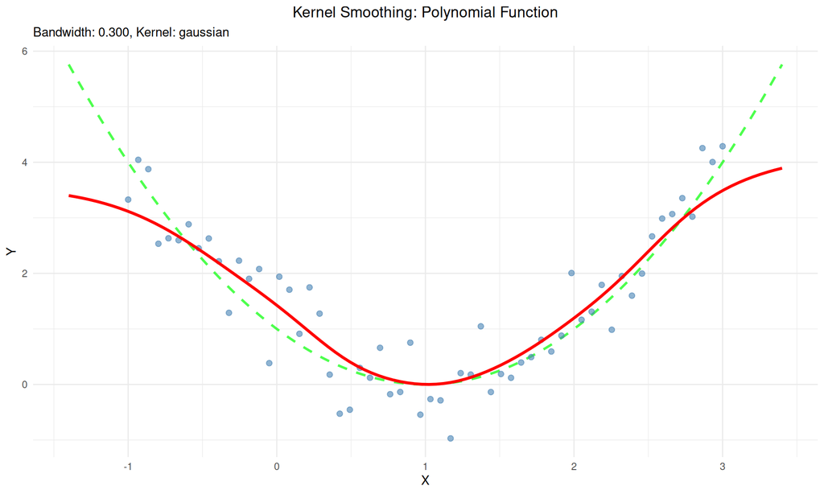

Kernel Smoothing: Polynomial Function

```r
# Generate noisy polynomial data: y = x² - 2x + 1 + ε
set.seed(456)
x_basic <- seq(-1, 3, length.out = 60)
true_basic <- x_basic^2 - 2*x_basic + 1
y_basic <- true_basic + rnorm(length(x_basic), sd = 0.5)

# Apply kernel smoothing
result_kernel_basic <- kernel_smooth(x_basic, y_basic,
                                    bandwidth = 0.3,
                                    kernel = "gaussian")

# Plot results
plot_smoothing_results(x_basic, y_basic, result_kernel_basic,
                      title = "Kernel Smoothing: Polynomial Function",
                      true_function = function(x) x^2 - 2*x + 1)
```

### 4.1.2 Spline Smoothing

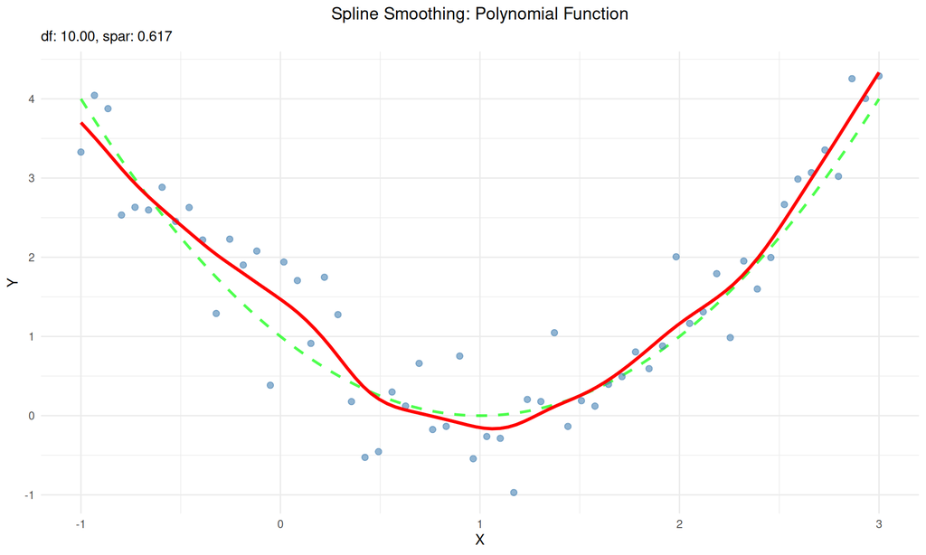

Spline Smoothing: Polynomial Function

```r
# Apply spline smoothing to the same data
result_spline_basic <- spline_smooth(x_basic, y_basic, df = 10)

# Plot results
plot_smoothing_results(x_basic, y_basic, result_spline_basic,
                      title = "Spline Smoothing: Polynomial Function",
                      true_function = function(x) x^2 - 2*x + 1)
```

### 4.1.3 Comparison: Kernel vs Spline

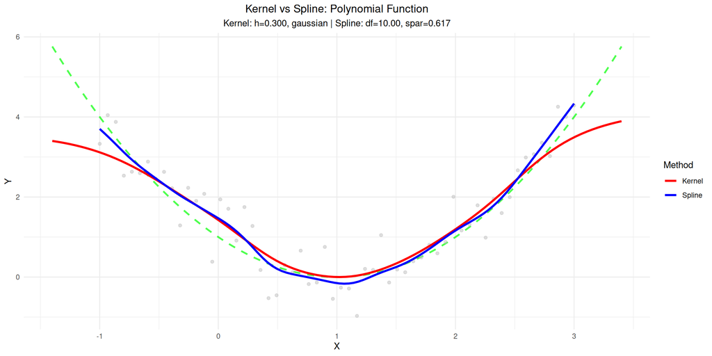

Comparison: Kernel vs Spline Smoothing on Polynomial Function

```r
# Compare both methods side-by-side
plot_smoothing_comparison(x_basic, y_basic,
                          result_kernel_basic,
                          result_spline_basic,
                          title = "Kernel vs Spline: Polynomial Function",
                          true_function = function(x) x^2 - 2*x + 1)
```

**Analysis of Results:**

This simple polynomial example ($y = x^2 - 2x + 1$) demonstrates key differences between the two methods:

## 4.2 Advanced Example: Comparing Bandwidths, Kernels, and Methods

### 4.2.1 Comparison: Kernel vs Spline Smoothing

This section demonstrates the key differences between kernel smoothing and spline smoothing on various types of data.

#### 4.2.1.1 Example 1: Sinusoidal Function

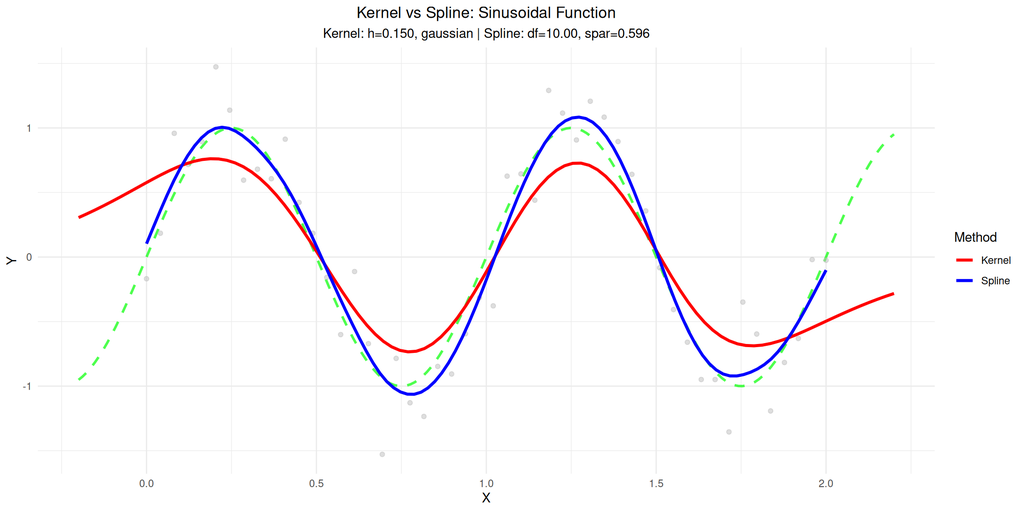

Kernel vs Spline: Sinusoidal Function

```r
# Generate noisy sinusoidal data
set.seed(123)
x_sin <- seq(0, 2, length.out = 50)
true_sin <- sin(2 * pi * x_sin)
y_sin <- true_sin + rnorm(length(x_sin), sd = 0.3)

# Apply both smoothing methods
result_kernel_sin <- kernel_smooth(x_sin, y_sin, bandwidth = 0.15, kernel = "gaussian")
result_spline_sin <- spline_smooth(x_sin, y_sin, df = 10)

# Compare
plot_smoothing_comparison(x_sin, y_sin,
                          result_kernel_sin,
                          result_spline_sin,
                          title = "Kernel vs Spline: Sinusoidal Function",
                          true_function = function(x) sin(2 * pi * x))
```

#### 4.2.1.2 Example 2: Polynomial Function with Boundary Effects

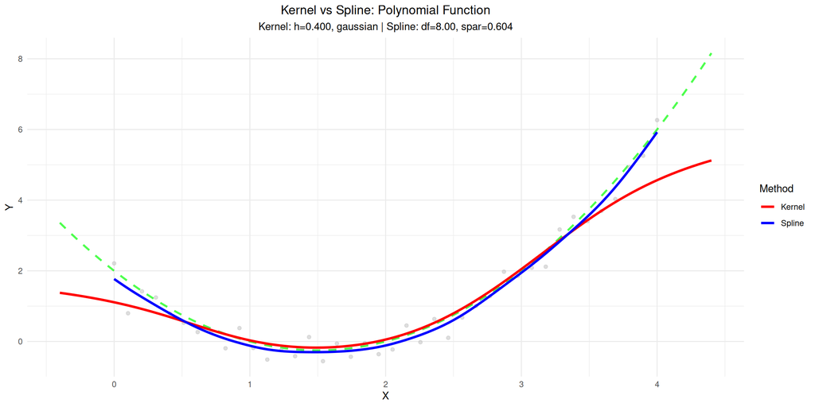

Kernel vs Spline: Polynomial Function

```r
# Generate polynomial data to test boundary behavior
set.seed(789)
x_poly <- seq(0, 4, length.out = 40)
true_poly <- x_poly^2 - 3*x_poly + 2
y_poly <- true_poly + rnorm(length(x_poly), sd = 0.4)

# Apply both methods
result_kernel_poly <- kernel_smooth(x_poly, y_poly, bandwidth = 0.4, kernel = "gaussian")
result_spline_poly <- spline_smooth(x_poly, y_poly, df = 8)

# Compare
plot_smoothing_comparison(x_poly, y_poly,
                          result_kernel_poly,
                          result_spline_poly,
                          title = "Kernel vs Spline: Polynomial Function",
                          true_function = function(x) x^2 - 3*x + 2)
```

**Observations:** - **Boundary behavior**: This is where the methods differ most significantly. Kernel smoothing shows clear bias at the edges (first and last points), where the kernel “runs out” of data on one side, causing the estimate to be pulled toward the mean. Spline smoothing handles boundaries much better due to its global optimization approach and natural spline constraints that enforce smooth behavior at boundaries. - **Smoothness**: Spline smoothing produces a more globally consistent curve, while kernel smoothing may show local variations that don’t reflect the true underlying trend. - **Middle region**: Both methods track the quadratic trend well in the middle region where data is abundant. - **Practical implication**: For applications where boundary values are critical (e.g., forecasting, edge detection), spline smoothing is preferred.

#### 4.2.1.3 Example 3: Time Series Data

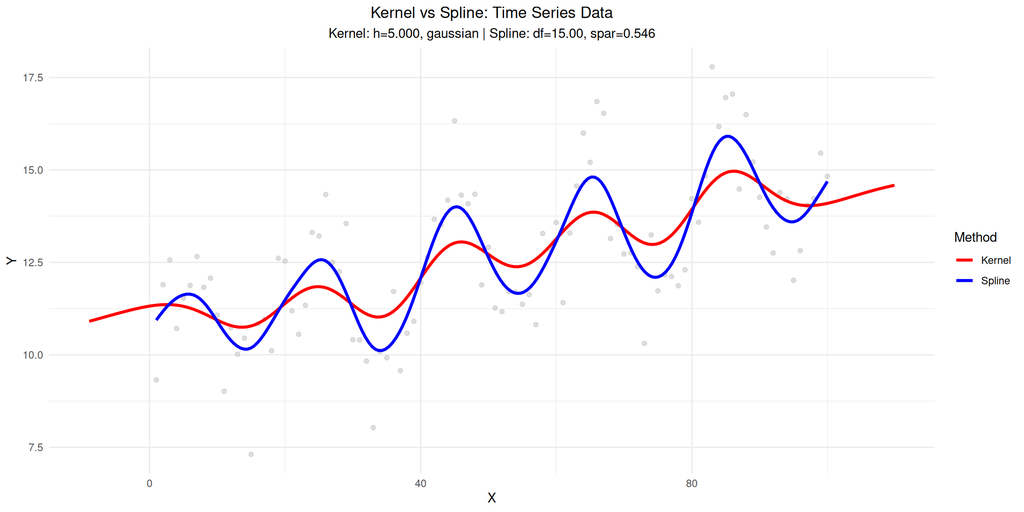

Kernel vs Spline: Time Series Data

```r
# Simulate time series with trend and noise
set.seed(456)
time <- 1:100
trend <- 0.05 * time + 10
seasonal <- 2 * sin(2 * pi * time / 20)
noise <- rnorm(length(time), sd = 1.0)
y_ts <- trend + seasonal + noise

# Apply both methods
result_kernel_ts <- kernel_smooth(time, y_ts, bandwidth = 5, kernel = "gaussian", n_grid = 200)
result_spline_ts <- spline_smooth(time, y_ts, df = 15, n_grid = 200)

# Compare
plot_smoothing_comparison(time, y_ts,
                          result_kernel_ts,
                          result_spline_ts,
                          title = "Kernel vs Spline: Time Series Data")
```

### 4.2.2 Effect of Bandwidth (Kernel) and Degrees of Freedom (Spline)

This section demonstrates how the key tuning parameters affect smoothness in both methods. Bandwidth ($h$) controls local averaging in kernel smoothing, while degrees of freedom ($df$) controls global smoothness in spline smoothing.

#### 4.2.2.1 Effect of Bandwidth on Kernel Smoothing

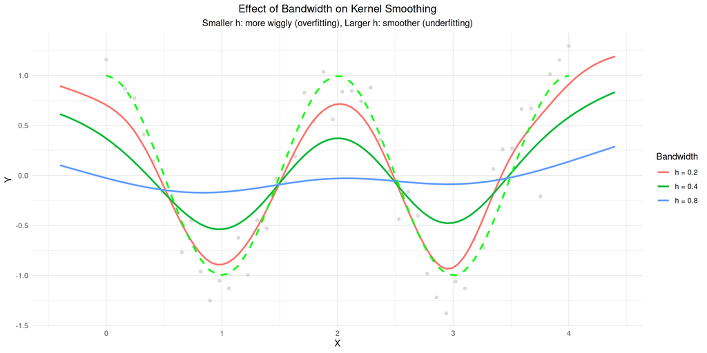

Effect of Different Bandwidths on Kernel Smoothing

```r
# Generate data
set.seed(789)
x_adv <- seq(0, 4, length.out = 50)
true_adv <- cos(pi * x_adv)
y_adv <- true_adv + rnorm(length(x_adv), sd = 0.3)

# Smooth with different bandwidths
bandwidths <- c(0.2, 0.4, 0.8)
results_bandwidth <- list()

for (h in bandwidths) {
  results_bandwidth[[as.character(h)]] <- kernel_smooth(x_adv, y_adv,
                                                         bandwidth = h,
                                                         kernel = "gaussian")
}

# Create comparison data frame
df_bandwidth <- data.frame()
for (h in names(results_bandwidth)) {
  df_temp <- data.frame(
    x = results_bandwidth[[h]]$x_grid,
    y = results_bandwidth[[h]]$y_smooth,
    bandwidth = paste("h =", h)
  )
  df_bandwidth <- rbind(df_bandwidth, df_temp)
}

# Plot comparison
ggplot() +
  geom_point(data = data.frame(x = x_adv, y = y_adv),
            aes(x = x, y = y), color = "gray", alpha = 0.5, size = 1.5) +
  geom_line(data = df_bandwidth, aes(x = x, y = y, color = bandwidth), linewidth = 1) +
  geom_line(data = data.frame(x = x_adv, y = true_adv),
           aes(x = x, y = y), linetype = "dashed", color = "green", linewidth = 1) +
  labs(title = "Effect of Bandwidth on Kernel Smoothing",
       subtitle = "Smaller h: more wiggly (overfitting), Larger h: smoother (underfitting)",
       x = "X",
       y = "Y",
       color = "Bandwidth") +
  theme_minimal() +
  theme(plot.title = element_text(hjust = 0.5),
        plot.subtitle = element_text(hjust = 0.5))
```

#### 4.2.2.2 Effect of Degrees of Freedom on Spline Smoothing

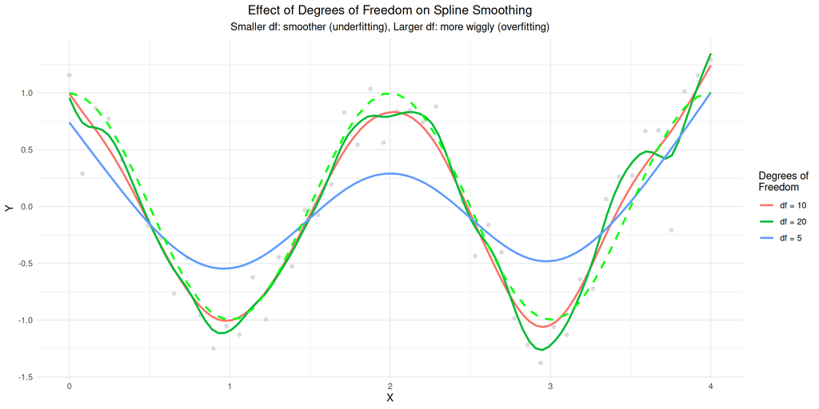

Effect of Different Degrees of Freedom on Spline Smoothing

```r
# Use the same data as bandwidth comparison
# Generate data (reuse from bandwidth comparison chunk)
set.seed(789)
x_adv_df <- seq(0, 4, length.out = 50)
true_adv_df <- cos(pi * x_adv_df)
y_adv_df <- true_adv_df + rnorm(length(x_adv_df), sd = 0.3)

# Smooth with different degrees of freedom
dfs <- c(5, 10, 20)
results_df <- list()

for (df_val in dfs) {
  results_df[[as.character(df_val)]] <- spline_smooth(x_adv_df, y_adv_df, df = df_val)
}

# Create comparison data frame
df_spline_list <- list()
for (df_val in names(results_df)) {
  result <- results_df[[df_val]]
  if (!is.null(result) && !is.null(result$x) && !is.null(result$y_smooth)) {
    n_points <- length(result$x)
    df_spline_list[[df_val]] <- data.frame(
      x = result$x,
      y = result$y_smooth,
      df = rep(paste("df =", df_val), n_points),
      stringsAsFactors = FALSE
    )
  }
}

if (length(df_spline_list) > 0) {
  df_spline <- do.call(rbind, df_spline_list)
} else {
  stop("No valid spline results to plot")
}

# Plot comparison
ggplot() +
  geom_point(data = data.frame(x = x_adv_df, y = y_adv_df),
            aes(x = x, y = y), color = "gray", alpha = 0.5, size = 1.5) +
  geom_line(data = df_spline, aes(x = x, y = y, color = df), linewidth = 1) +
  geom_line(data = data.frame(x = x_adv_df, y = true_adv_df),
           aes(x = x, y = y), linetype = "dashed", color = "green", linewidth = 1) +
  labs(title = "Effect of Degrees of Freedom on Spline Smoothing",
       subtitle = "Smaller df: smoother (underfitting), Larger df: more wiggly (overfitting)",
       x = "X",
       y = "Y",
       color = "Degrees of\nFreedom") +
  theme_minimal() +
  theme(plot.title = element_text(hjust = 0.5),
        plot.subtitle = element_text(hjust = 0.5))
```

**Key Points:** - **Low degrees of freedom (df = 5)**: Very smooth curve, similar to a low-order polynomial. May underfit complex patterns. - **Medium degrees of freedom (df = 10)**: Balanced smoothness and flexibility. Often the optimal choice. - **High degrees of freedom (df = 20)**: More flexible curve that can capture local variations. Risk of overfitting.

#### 4.2.2.3 Side-by-Side Comparison: Bandwidth vs Degrees of Freedom

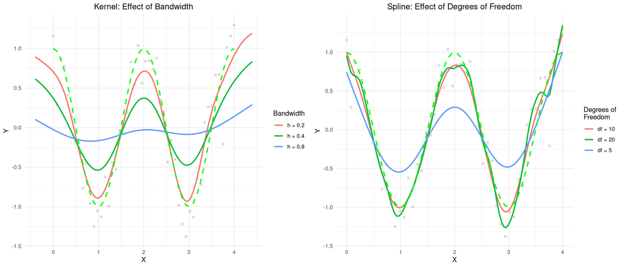

Side-by-Side: Bandwidth (Kernel) vs Degrees of Freedom (Spline)

```r
# Create side-by-side comparison
if (!require(gridExtra, quietly = TRUE)) {
  install.packages("gridExtra", repos = "https://cran.r-project.org")
  library(gridExtra)
}

# Use the same data for both plots (from bandwidth comparison)
# Generate data (reuse from bandwidth comparison chunk)
set.seed(789)
x_adv_comp <- seq(0, 4, length.out = 50)
true_adv_comp <- cos(pi * x_adv_comp)
y_adv_comp <- true_adv_comp + rnorm(length(x_adv_comp), sd = 0.3)

# Recreate bandwidth results for comparison
bandwidths_comp <- c(0.2, 0.4, 0.8)
results_bandwidth_comp <- list()
for (h in bandwidths_comp) {
  results_bandwidth_comp[[as.character(h)]] <- kernel_smooth(x_adv_comp, y_adv_comp,
                                                               bandwidth = h,
                                                               kernel = "gaussian")
}
df_bandwidth_comp_list <- list()
for (h in names(results_bandwidth_comp)) {
  result <- results_bandwidth_comp[[h]]
  if (!is.null(result) && !is.null(result$x_grid) && !is.null(result$y_smooth)) {
    n_points <- length(result$x_grid)
    df_bandwidth_comp_list[[h]] <- data.frame(
      x = result$x_grid,
      y = result$y_smooth,
      bandwidth = rep(paste("h =", h), n_points),
      stringsAsFactors = FALSE
    )
  }
}
if (length(df_bandwidth_comp_list) > 0) {
  df_bandwidth_comp <- do.call(rbind, df_bandwidth_comp_list)
} else {
  df_bandwidth_comp <- data.frame(x = numeric(0), y = numeric(0), bandwidth = character(0))
}

# Recreate spline results for comparison
dfs_comp <- c(5, 10, 20)
results_df_comp <- list()
for (df_val in dfs_comp) {
  results_df_comp[[as.character(df_val)]] <- spline_smooth(x_adv_comp, y_adv_comp, df = df_val)
}
df_spline_comp_list <- list()
for (df_val in names(results_df_comp)) {
  result <- results_df_comp[[df_val]]
  if (!is.null(result) && !is.null(result$x) && !is.null(result$y_smooth)) {
    n_points <- length(result$x)
    df_spline_comp_list[[df_val]] <- data.frame(
      x = result$x,
      y = result$y_smooth,
      df = rep(paste("df =", df_val), n_points),
      stringsAsFactors = FALSE
    )
  }
}
if (length(df_spline_comp_list) > 0) {
  df_spline_comp <- do.call(rbind, df_spline_comp_list)
} else {
  df_spline_comp <- data.frame(x = numeric(0), y = numeric(0), df = character(0))
}

# Kernel smoothing with different bandwidths
p1 <- ggplot() +
  geom_point(data = data.frame(x = x_adv_comp, y = y_adv_comp),
            aes(x = x, y = y), color = "gray", alpha = 0.5, size = 1.5) +
  geom_line(data = df_bandwidth_comp, aes(x = x, y = y, color = bandwidth), linewidth = 1) +
  geom_line(data = data.frame(x = x_adv_comp, y = true_adv_comp),
           aes(x = x, y = y), linetype = "dashed", color = "green", linewidth = 1) +
  labs(title = "Kernel: Effect of Bandwidth",
       x = "X", y = "Y", color = "Bandwidth") +
  theme_minimal() +
  theme(plot.title = element_text(hjust = 0.5))

# Spline smoothing with different degrees of freedom
p2 <- ggplot() +
  geom_point(data = data.frame(x = x_adv_comp, y = y_adv_comp),
            aes(x = x, y = y), color = "gray", alpha = 0.5, size = 1.5) +
  geom_line(data = df_spline_comp, aes(x = x, y = y, color = df), linewidth = 1) +
  geom_line(data = data.frame(x = x_adv_comp, y = true_adv_comp),
           aes(x = x, y = y), linetype = "dashed", color = "green", linewidth = 1) +
  labs(title = "Spline: Effect of Degrees of Freedom",
       x = "X", y = "Y", color = "Degrees of\nFreedom") +
  theme_minimal() +
  theme(plot.title = element_text(hjust = 0.5))

grid.arrange(p1, p2, ncol = 2)
```

### 4.2.3 Comparison of Kernel Functions

**Note:** This section is specific to kernel smoothing. Spline smoothing does not use kernel functions - it uses basis functions (typically natural cubic splines) that are determined by the data structure itself. The smoothness in splines is controlled by the regularization parameter ($\lambda$ or degrees of freedom), not by choosing different kernel shapes.

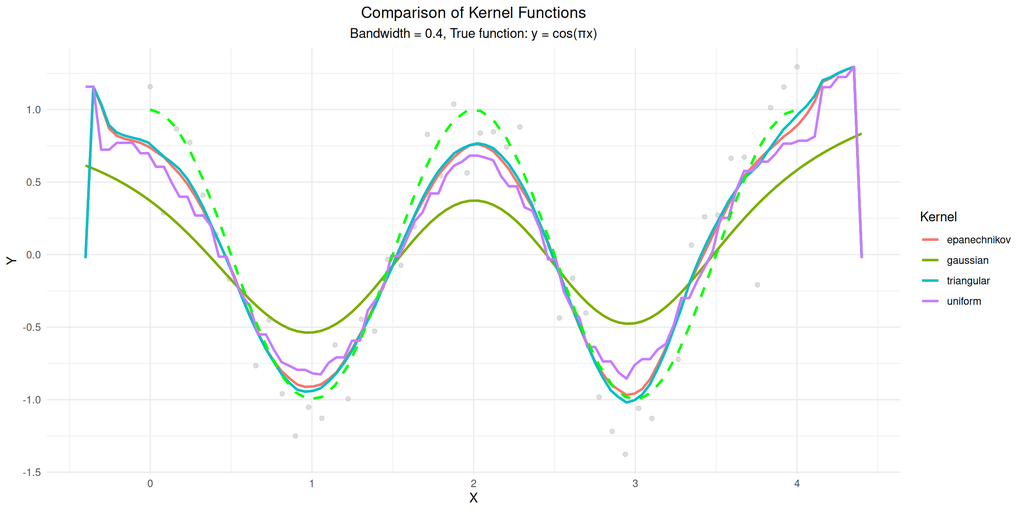

Comparison of Different Kernel Functions

```r
# Smooth with different kernels (same bandwidth)
kernels <- c("gaussian", "epanechnikov", "uniform", "triangular")
results_kernels <- list()

for (k in kernels) {
  results_kernels[[k]] <- kernel_smooth(x_adv, y_adv,
                                        bandwidth = 0.4,
                                        kernel = k)
}

# Create comparison data frame
df_kernels <- data.frame()
for (k in names(results_kernels)) {
  df_temp <- data.frame(
    x = results_kernels[[k]]$x_grid,
    y = results_kernels[[k]]$y_smooth,
    kernel = k
  )
  df_kernels <- rbind(df_kernels, df_temp)
}

# Plot comparison
ggplot() +
  geom_point(data = data.frame(x = x_adv, y = y_adv),
            aes(x = x, y = y), color = "gray", alpha = 0.5, size = 1.5) +
  geom_line(data = df_kernels, aes(x = x, y = y, color = kernel), linewidth = 1) +
  geom_line(data = data.frame(x = x_adv, y = true_adv),
           aes(x = x, y = y), linetype = "dashed", color = "green", linewidth = 1) +
  labs(title = "Comparison of Kernel Functions",
       subtitle = "Bandwidth = 0.4, True function: y = cos(πx)",
       x = "X",
       y = "Y",
       color = "Kernel") +
  theme_minimal() +
  theme(plot.title = element_text(hjust = 0.5),
        plot.subtitle = element_text(hjust = 0.5))
```

# 5 Performance Analysis

## 5.1 Complexity

### 5.1.1 Kernel Smoothing Complexity

**Time Complexity: $O(n \cdot m)$**

Where: - $n$ = number of data points - $m$ = number of evaluation points (grid size)

**Mathematical Explanation:**

The complexity arises from the nested loop structure: - **Outer loop**: Iterates over $m$ evaluation points (grid size) - **Inner loop**: For each evaluation point, scans through all $n$ data points - **Operations per iteration**: Distance calculation $O(1)$, kernel evaluation $O(1)$, weighted sum $O(1)$

**Total operations**: $m \times n \times O(1) = O(m \cdot n)$

**Space Complexity**: $O(n + m)$ for storing data and results

### 5.1.2 Spline Smoothing Complexity

**Time Complexity: $O(n + m)$**

Where: - $n$ = number of data points - $m$ = number of evaluation points (grid size)

**Mathematical Explanation:**

1. **Basis Construction**: $O(n)$ - creating $n$ natural cubic spline basis functions
2. **Matrix Setup**: $O(n)$ - constructing banded matrices (bandwidth ~4 for cubic splines)
3. **Solving Linear System**: $O(n)$ - using banded matrix solver (not $O(n^3)$ like dense matrices)
4. **Evaluation**: $O(m)$ - evaluating spline at $m$ points after fitting

**Total**: $O(n) + O(n) + O(n) + O(m) = O(n + m)$

**Space Complexity**: $O(n + m)$ for storing basis matrices and results

### 5.1.3 Comparative Complexity

| Aspect | Kernel Smoothing | Spline Smoothing |
| --- | --- | --- |
| **Time Complexity** | $O(n \cdot m)$ | $O(n + m)$ |
| **Space Complexity** | $O(n + m)$ | $O(n + m)$ |
| **Scaling Behavior** | Quadratic in $n$ and $m$ | Linear in $n$ and $m$ |
| **Large Dataset Performance** | Slow (quadratic) | Fast (linear) |

## 5.2 Benchmarks

### 5.2.1 Performance Comparison: Small to Medium Datasets

```r
# Benchmark computation time for different data sizes (small to medium)
set.seed(123)
data_sizes_small <- c(100, 500, 1000, 5000, 10000)
times_kernel_small <- numeric(length(data_sizes_small))
times_spline_small <- numeric(length(data_sizes_small))
m_grid <- 100  # Fixed grid size

cat("Benchmarking small to medium datasets...\n")
```

```
## Benchmarking small to medium datasets...
```

```r
for (i in seq_along(data_sizes_small)) {
  n <- data_sizes_small[i]
  x_bench <- seq(0, 10, length.out = n)
  y_bench <- sin(x_bench) + rnorm(n, sd = 0.3)

  # Benchmark kernel smoothing
  start_time <- Sys.time()
  result_kernel <- kernel_smooth(x_bench, y_bench, bandwidth = 0.5, n_grid = m_grid)
  end_time <- Sys.time()
  times_kernel_small[i] <- as.numeric(difftime(end_time, start_time, units = "secs"))

  # Benchmark spline smoothing
  start_time <- Sys.time()
  result_spline <- spline_smooth(x_bench, y_bench, df = 10)
  end_time <- Sys.time()
  times_spline_small[i] <- as.numeric(difftime(end_time, start_time, units = "secs"))

  cat(sprintf("n=%d: Kernel=%.3fs, Spline=%.3fs\n", n, times_kernel_small[i], times_spline_small[i]))
}
```

```
## n=100: Kernel=0.004s, Spline=0.001s
## n=500: Kernel=0.022s, Spline=0.001s
## n=1000: Kernel=0.029s, Spline=0.001s
## n=5000: Kernel=0.150s, Spline=0.003s
## n=10000: Kernel=0.287s, Spline=0.005s
```

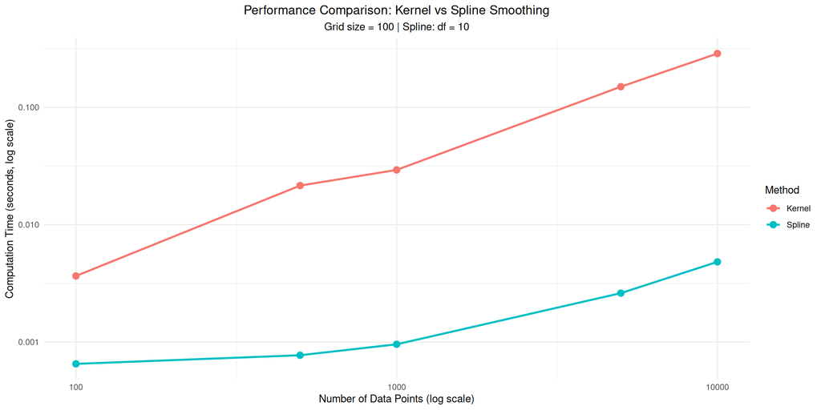

Performance Comparison: Small to Medium Datasets

```r
# Create comparison data frame
df_perf_small <- data.frame(
  n = rep(data_sizes_small, 2),
  time = c(times_kernel_small, times_spline_small),
  method = rep(c("Kernel", "Spline"), each = length(data_sizes_small))
)

# Plot performance comparison
ggplot(df_perf_small, aes(x = n, y = time, color = method)) +
  geom_point(size = 3) +
  geom_line(linewidth = 1) +
  scale_x_log10() +
  scale_y_log10() +
  labs(title = "Performance Comparison: Kernel vs Spline Smoothing",
       subtitle = paste("Grid size =", m_grid, "| Spline: df = 10"),
       x = "Number of Data Points (log scale)",
       y = "Computation Time (seconds, log scale)",
       color = "Method") +
  theme_minimal() +
  theme(plot.title = element_text(hjust = 0.5),
        plot.subtitle = element_text(hjust = 0.5))
```

```r
cat("\nPerformance results (small to medium):\n")
```

```
##
## Performance results (small to medium):
```

```r
print(df_perf_small)
```

```
##        n         time method
## 1    100 0.0036559105 Kernel
## 2    500 0.0215325356 Kernel
## 3   1000 0.0292758942 Kernel
## 4   5000 0.1498341560 Kernel
## 5  10000 0.2870843410 Kernel
## 6    100 0.0006520748 Spline
## 7    500 0.0007722378 Spline
## 8   1000 0.0009570122 Spline
## 9   5000 0.0026111603 Spline
## 10 10000 0.0048203468 Spline
```

### 5.2.2 Performance Comparison: Large Datasets

```r
# Benchmark computation time for large datasets
set.seed(123)
# Use progressively larger datasets, but be reasonable with computation time
data_sizes_large <- c(1000, 5000, 10000, 50000, 100000)
times_kernel_large <- numeric(length(data_sizes_large))
times_spline_large <- numeric(length(data_sizes_large))
m_grid_large <- 200  # Larger grid for better visualization

cat("\nBenchmarking large datasets (this may take a while)...\n")
```

```
##
## Benchmarking large datasets (this may take a while)...
```

```r
cat("Note: Kernel smoothing becomes very slow for large datasets due to O(n·m) complexity.\n\n")
```

```
## Note: Kernel smoothing becomes very slow for large datasets due to O(n·m) complexity.
```

```r
for (i in seq_along(data_sizes_large)) {
  n <- data_sizes_large[i]
  x_bench <- seq(0, 10, length.out = n)
  y_bench <- sin(x_bench) + rnorm(n, sd = 0.3)

  # Benchmark spline smoothing (fast, O(n))
  start_time <- Sys.time()
  result_spline <- spline_smooth(x_bench, y_bench, df = 15)
  end_time <- Sys.time()
  times_spline_large[i] <- as.numeric(difftime(end_time, start_time, units = "secs"))

  # Benchmark kernel smoothing (slow for large n, O(n·m))
  # Skip kernel for very large datasets to save time, or use smaller grid
  if (n <= 10000) {
    start_time <- Sys.time()
    result_kernel <- kernel_smooth(x_bench, y_bench, bandwidth = 0.5, n_grid = m_grid_large)
    end_time <- Sys.time()
    times_kernel_large[i] <- as.numeric(difftime(end_time, start_time, units = "secs"))
  } else {
    # For very large datasets, kernel smoothing is too slow - estimate or skip
    times_kernel_large[i] <- NA
    cat(sprintf("n=%d: Kernel=SKIPPED (too slow), Spline=%.3fs\n", n, times_spline_large[i]))
    next
  }

  cat(sprintf("n=%d: Kernel=%.3fs, Spline=%.3fs (Speedup: %.1fx)\n",
              n, times_kernel_large[i], times_spline_large[i],
              times_kernel_large[i] / times_spline_large[i]))
}
```

```
## n=1000: Kernel=0.064s, Spline=0.003s (Speedup: 22.1x)
## n=5000: Kernel=0.301s, Spline=0.003s (Speedup: 112.3x)
## n=10000: Kernel=0.616s, Spline=0.005s (Speedup: 126.8x)
## n=50000: Kernel=SKIPPED (too slow), Spline=0.023s
## n=100000: Kernel=SKIPPED (too slow), Spline=0.048s
```

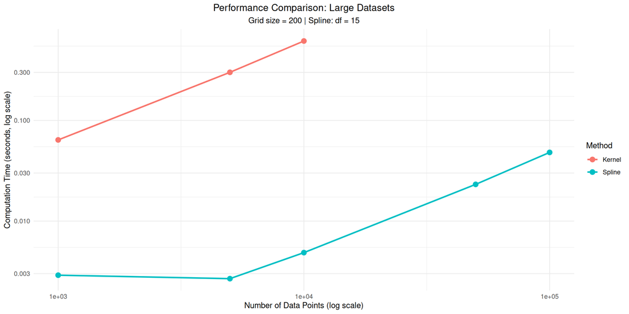

Performance Comparison: Large Datasets

```r
# Create comparison data frame
df_perf_large <- data.frame(
  n = rep(data_sizes_large, 2),
  time = c(times_kernel_large, times_spline_large),
  method = rep(c("Kernel", "Spline"), each = length(data_sizes_large))
)

# Remove NA values for plotting
df_perf_large_clean <- df_perf_large[!is.na(df_perf_large$time), ]

# Plot performance comparison
ggplot(df_perf_large_clean, aes(x = n, y = time, color = method)) +
  geom_point(size = 3) +
  geom_line(linewidth = 1) +
  scale_x_log10() +
  scale_y_log10() +
  labs(title = "Performance Comparison: Large Datasets",
       subtitle = paste("Grid size =", m_grid_large, "| Spline: df = 15"),
       x = "Number of Data Points (log scale)",
       y = "Computation Time (seconds, log scale)",
       color = "Method") +
  theme_minimal() +
  theme(plot.title = element_text(hjust = 0.5),
        plot.subtitle = element_text(hjust = 0.5))
```

```r
cat("\nPerformance results (large datasets):\n")
```

```
##
## Performance results (large datasets):
```

```r
print(df_perf_large_clean)
```

```
##        n        time method
## 1  1e+03 0.064025164 Kernel
## 2  5e+03 0.300665379 Kernel
## 3  1e+04 0.615579367 Kernel
## 6  1e+03 0.002897739 Spline
## 7  5e+03 0.002676964 Spline
## 8  1e+04 0.004856586 Spline
## 9  5e+04 0.023154974 Spline
## 10 1e+05 0.048109293 Spline
```

### 5.2.3 Extreme Scale Test: Up to 1,000,000 Records

```r
# Test with extremely large datasets
set.seed(123)
# Use exponential progression to test scaling
data_sizes_extreme <- c(10000, 50000, 100000, 500000, 1000000)
times_spline_extreme <- numeric(length(data_sizes_extreme))
times_kernel_extreme <- numeric(length(data_sizes_extreme))

cat("\n=== EXTREME SCALE BENCHMARK ===\n")
```

```
##
## === EXTREME SCALE BENCHMARK ===
```

```r
cat("Testing with datasets up to 1,000,000 records...\n")
```

```
## Testing with datasets up to 1,000,000 records...
```

```r
cat("Note: Kernel smoothing will be extremely slow for large datasets.\n\n")
```

```
## Note: Kernel smoothing will be extremely slow for large datasets.
```

```r
for (i in seq_along(data_sizes_extreme)) {
  n <- data_sizes_extreme[i]
  cat(sprintf("Testing n = %d...\n", n))

  # Generate data
  x_bench <- seq(0, 10, length.out = n)
  y_bench <- sin(x_bench) + rnorm(n, sd = 0.3)

  # Benchmark spline smoothing (should handle large datasets well)
  start_time <- Sys.time()
  result_spline <- spline_smooth(x_bench, y_bench, df = 20)
  end_time <- Sys.time()
  times_spline_extreme[i] <- as.numeric(difftime(end_time, start_time, units = "secs"))

  # For kernel smoothing, only test on smaller datasets or use very small grid
  # For n > 50,000, kernel becomes too slow even with small grid
  if (n <= 50000) {
    # Use adaptive grid size: smaller grid for larger datasets
    m_small <- max(20, min(100, round(200 * 10000 / n)))  # Adaptive grid size
    cat(sprintf("  Kernel smoothing with grid size = %d...\n", m_small))
    start_time <- Sys.time()
    result_kernel <- kernel_smooth(x_bench, y_bench, bandwidth = 0.5, n_grid = m_small)
    end_time <- Sys.time()
    times_kernel_extreme[i] <- as.numeric(difftime(end_time, start_time, units = "secs"))
    cat(sprintf("  n=%d: Kernel=%.2fs (grid=%d), Spline=%.2fs (Speedup: %.1fx)\n",
                n, times_kernel_extreme[i], m_small, times_spline_extreme[i],
                times_kernel_extreme[i] / times_spline_extreme[i]))
  } else {
    # For very large datasets (n > 50,000), kernel is impractical
    # Estimate based on O(n·m) complexity
    if (i > 1 && !is.na(times_kernel_extreme[i-1])) {
      # Estimate: time scales with n·m, but we use smaller grid
      prev_n <- data_sizes_extreme[i-1]
      prev_time <- times_kernel_extreme[i-1]
      m_estimate <- max(10, round(200 * 10000 / n))
      estimated_time <- prev_time * (n / prev_n) * (m_estimate / 50)  # Rough estimate
      times_kernel_extreme[i] <- estimated_time
      cat(sprintf("  n=%d: Kernel=ESTIMATED ~%.0fs (impractical to run), Spline=%.2fs\n",
                  n, estimated_time, times_spline_extreme[i]))
    } else {
      times_kernel_extreme[i] <- NA
      cat(sprintf("  n=%d: Kernel=SKIPPED (impractical), Spline=%.2fs\n",
                  n, times_spline_extreme[i]))
    }
  }
}
```

```
## Testing n = 10000...
##   Kernel smoothing with grid size = 100...
##   n=10000: Kernel=0.26s (grid=100), Spline=0.01s (Speedup: 45.0x)
## Testing n = 50000...
##   Kernel smoothing with grid size = 40...
##   n=50000: Kernel=0.51s (grid=40), Spline=0.03s (Speedup: 17.2x)
## Testing n = 100000...
##   n=100000: Kernel=ESTIMATED ~0s (impractical to run), Spline=0.05s
## Testing n = 500000...
##   n=500000: Kernel=ESTIMATED ~0s (impractical to run), Spline=0.57s
## Testing n = 1000000...
##   n=1000000: Kernel=ESTIMATED ~0s (impractical to run), Spline=0.73s
```

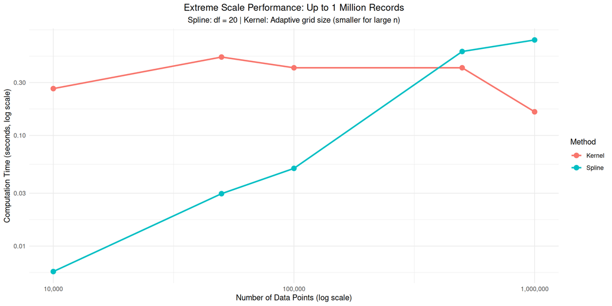

Extreme Scale Performance: Up to 1 Million Records

```r
# Create comparison data frame
df_perf_extreme <- data.frame(
  n = rep(data_sizes_extreme, 2),
  time = c(times_kernel_extreme, times_spline_extreme),
  method = rep(c("Kernel", "Spline"), each = length(data_sizes_extreme))
)

# Remove NA values for plotting
df_perf_extreme_clean <- df_perf_extreme[!is.na(df_perf_extreme$time), ]

# Plot performance comparison
p <- ggplot(df_perf_extreme_clean, aes(x = n, y = time, color = method)) +
  geom_point(size = 3) +
  geom_line(linewidth = 1) +
  scale_x_log10(labels = scales::comma) +
  scale_y_log10(labels = scales::comma) +
  labs(title = "Extreme Scale Performance: Up to 1 Million Records",
       subtitle = "Spline: df = 20 | Kernel: Adaptive grid size (smaller for large n)",
       x = "Number of Data Points (log scale)",
       y = "Computation Time (seconds, log scale)",
       color = "Method") +
  theme_minimal() +
  theme(plot.title = element_text(hjust = 0.5),
        plot.subtitle = element_text(hjust = 0.5))

print(p)
```

```r
cat("\n=== EXTREME SCALE RESULTS ===\n")
```

```
##
## === EXTREME SCALE RESULTS ===
```

```r
print(df_perf_extreme_clean)
```

```
##        n        time method
## 1  1e+04 0.264733076 Kernel
## 2  5e+04 0.510484934 Kernel
## 3  1e+05 0.408387947 Kernel
## 4  5e+05 0.408387947 Kernel
## 5  1e+06 0.163355179 Kernel
## 6  1e+04 0.005884171 Spline
## 7  5e+04 0.029745579 Spline
## 8  1e+05 0.050360918 Spline
## 9  5e+05 0.572919846 Spline
## 10 1e+06 0.728431940 Spline
```

```r
# Calculate scaling factors
cat("\n=== SCALING ANALYSIS ===\n")
```

```
##
## === SCALING ANALYSIS ===
```

```r
spline_times <- times_spline_extreme[!is.na(times_spline_extreme)]
spline_sizes <- data_sizes_extreme[!is.na(times_spline_extreme)]

if (length(spline_times) > 1) {
  cat("\nSpline Smoothing Scaling (Theoretical: O(n)):\n")
  for (i in 2:length(spline_times)) {
    size_ratio <- spline_sizes[i] / spline_sizes[i-1]
    time_ratio <- spline_times[i] / spline_times[i-1]
    cat(sprintf("  %d -> %d: Size ratio=%.1fx, Time ratio=%.2fx (Expected: %.1fx)\n",
                spline_sizes[i-1], spline_sizes[i], size_ratio, time_ratio, size_ratio))
  }
}
```

```
##
## Spline Smoothing Scaling (Theoretical: O(n)):
##   10000 -> 50000: Size ratio=5.0x, Time ratio=5.06x (Expected: 5.0x)
##   50000 -> 100000: Size ratio=2.0x, Time ratio=1.69x (Expected: 2.0x)
##   100000 -> 500000: Size ratio=5.0x, Time ratio=11.38x (Expected: 5.0x)
##   500000 -> 1000000: Size ratio=2.0x, Time ratio=1.27x (Expected: 2.0x)
```

### 5.2.4 Effect of Grid Size on Kernel Smoothing

```r
# Test effect of grid size m on kernel smoothing
n_fixed <- 10000
grid_sizes <- c(50, 100, 200, 500, 1000)
times_grid <- numeric(length(grid_sizes))

set.seed(123)
x_grid_test <- seq(0, 10, length.out = n_fixed)
y_grid_test <- sin(x_grid_test) + rnorm(n_fixed, sd = 0.3)

cat("Testing effect of grid size on kernel smoothing (n =", n_fixed, ")...\n")
```

```
## Testing effect of grid size on kernel smoothing (n = 10000 )...
```

```r
for (i in seq_along(grid_sizes)) {
  m <- grid_sizes[i]
  start_time <- Sys.time()
  result <- kernel_smooth(x_grid_test, y_grid_test, bandwidth = 0.5, n_grid = m)
  end_time <- Sys.time()
  times_grid[i] <- as.numeric(difftime(end_time, start_time, units = "secs"))
  cat(sprintf("  Grid size = %d: Time = %.3fs\n", m, times_grid[i]))
}
```

```
##   Grid size = 50: Time = 0.133s
##   Grid size = 100: Time = 0.262s
##   Grid size = 200: Time = 0.508s
##   Grid size = 500: Time = 1.380s
##   Grid size = 1000: Time = 2.474s
```

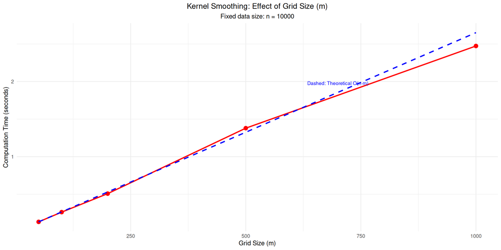

Effect of Grid Size on Kernel Smoothing Performance

```r
df_grid <- data.frame(
  m = grid_sizes,
  time = times_grid,
  theoretical = (grid_sizes * n_fixed) / (grid_sizes[1] * n_fixed)  # O(n·m) scaling
)

ggplot(df_grid, aes(x = m, y = time)) +
  geom_point(size = 3, color = "red") +
  geom_line(linewidth = 1, color = "red") +
  geom_line(aes(y = time[1] * theoretical), linetype = "dashed", color = "blue", linewidth = 1) +
  labs(title = "Kernel Smoothing: Effect of Grid Size (m)",
       subtitle = paste("Fixed data size: n =", n_fixed),
       x = "Grid Size (m)",
       y = "Computation Time (seconds)") +
  theme_minimal() +
  theme(plot.title = element_text(hjust = 0.5),
        plot.subtitle = element_text(hjust = 0.5)) +
  annotate("text", x = max(grid_sizes) * 0.7, y = max(times_grid) * 0.8,
           label = "Dashed: Theoretical O(n·m)", color = "blue", size = 3)
```

```r
cat("\nGrid size effect analysis:\n")
```

```
##
## Grid size effect analysis:
```

```r
cat("Theoretical prediction: Time should scale linearly with grid size m\n")
```

```
## Theoretical prediction: Time should scale linearly with grid size m
```

```r
cat("Correlation between grid size and time:", cor(grid_sizes, times_grid), "\n")
```

```
## Correlation between grid size and time: 0.9981407
```

### 5.2.5 Performance Summary and Recommendations

# 6 References

# 7 Appendix